# Advanced Bioinformatics 2026 Assessment

Student ID: 2506253

# Task 3.1

Using the “:” operator to generate all integers between 5 to 55 and the “sum ()” function to add all the integers together.

```r
sum (5:55)
```

```
## [1] 1530
```

## Task 3.2

sumfun is defined as a function with n as an singular input paramter. This function uses “:” to generate of all integers from 5 to n, with the sum() command adding all the numbers together. This function is then performed when n=10,20 and 100.

```r
sumfun <- function(n) {
   total <- sum(5:n)
   return (total)}

sumfun(10)
```

```
## [1] 45
```

```r
sumfun(20)
```

```
## [1] 200
```

```r
sumfun(100)
```

```
## [1] 5040
```

## Task 3.3

This R script creates a function which generates the first numbers of the Fibonacci sequence in this case n=12, so it calculates the first 12 entries. It also indicates that each fibonacci number is the sum of the two previous numbers starting with 1,1. Numeric vectors were manually inserted for the first two entries, however the loop for(i in 3:n) was used to calculate the fibonacci numbers from the 3rd entry onwards.

```r
# Create a function to generate the first n entries of the fibonacci sequence
fibonacci_sequence <- function(n) {
# Create a numeric vector
  fib_num <- numeric (n)
  # Manually insert the first two entries of the fibonacci sequence.
  fib_num [1] <- 1  # Entry 1 = 1
  fib_num [2] <- 1  # Entry 2 = 1

# Begin the loop from the 3rd entry
  for (i in 3:n) {
  fib_num[i] <- fib_num[i-1] + fib_num[i-2]
}
return (fib_num)
}
#  Calculate and generate the first 12 entries of the fibonacci sequence.
fibonacci_sequence(12)
```

```
##  [1]   1   1   2   3   5   8  13  21  34  55  89 144
```

## Task 3.4

The mtcars dataset bundled with R was used to create a boxplot of miles per gallon as a function of the number of gears using ggplot2. The aes () function highlights the variables used in the plot, in this case gear is converted to a factor using as. factor() to ensure that it is converted into a categorical variable, this ensures that a separate boxplot is drawn for each gear (3,4,or 5). The additional fill = as.factor (gear) aesthetic inside geom_boxplot () is used to colour each box by the number of gears. Lastly, the labs() function was used to appropriately provide a title and label the x axis, y axis and the fill.

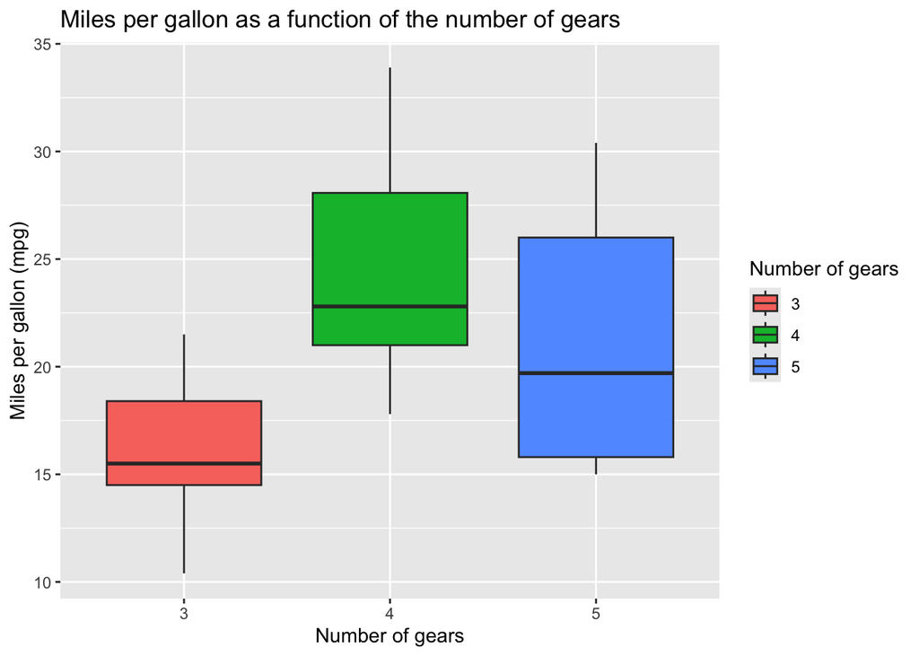

```r
#Load the ggplot2 library for plotting
library(ggplot2)
#Generating a box plot
ggplot(data = mtcars, aes(x= as.factor(gear), y= mpg)) + geom_boxplot(aes(fill= as.factor(gear) )) + labs(title = "Miles per gallon as a function of the number of gears",
       x = "Number of gears",
       y = "Miles per gallon (mpg)",
       fill = "Number of gears")
```

## Task 3.5

A simple linear model is fitted using the lm() function on the cars dataset, with breaking distance as the dependent variable (y) and speed as the independent variable (x), following the simple linear relationship typically expressed as y~x. The summary() command is then used on the fitted lm model to extract detailed parameter values such as fitted slope (3.9324), intercept (-17.5791 ), and their standard errors (6.7584, 0.4155) . ?cars was used to access the R help documentation of the cars dataset showing that speed was measured in miles per hour (mph) and distance was measured in feet (ft).

```r
y <- cars$dist; x<-cars$speed;
#Fit the linear model using lm
model <- lm(formula = "y~x")
#Parameter values of fitted model
summary(model)
```

```
##
## Call:
## lm(formula = "y~x")
##
## Residuals:
##     Min      1Q  Median      3Q     Max
## -29.069  -9.525  -2.272   9.215  43.201
##
## Coefficients:
##             Estimate Std. Error t value Pr(>|t|)
## (Intercept) -17.5791     6.7584  -2.601   0.0123 *
## x             3.9324     0.4155   9.464 1.49e-12 ***
## ---
## Signif. codes:  0 '***' 0.001 '**' 0.01 '*' 0.05 '.' 0.1 ' ' 1
##
## Residual standard error: 15.38 on 48 degrees of freedom
## Multiple R-squared:  0.6511, Adjusted R-squared:  0.6438
## F-statistic: 89.57 on 1 and 48 DF,  p-value: 1.49e-12
```

```r
# View cars dataset R documentation to check variable units
?cars
```

## Task 3.6

The ggplot2 library was loaded into R to plot the data points derived from Task 3.5. ggplot() was used to specify the expressions needed to plot from the cars dataset in this case speed in the x axis and distance in the y axis. The geompoint() function was used to visualise the speed and distance data points through a scatter plot. Following this, the linear fit was plotted using geom_smooth (method=“lm”,formula=“y~x”) which visualises the relationship between the x and y variables. Lastly, the labs() function was used to appropriately provide a title and label the x and y axis

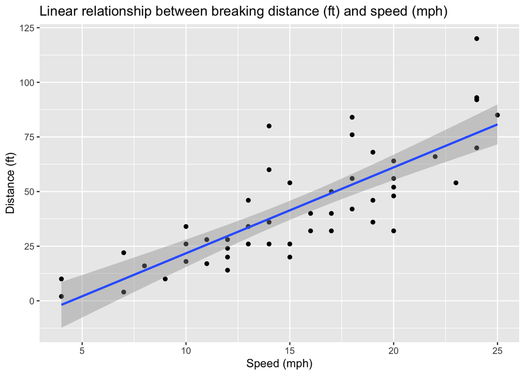

```r
# Load the ggplot2 library for plotting
library(ggplot2)
# Create a scatter plot showing the relationship between speed and distance and add the linear fit.
ggplot(cars,aes(x= speed,y= dist)) + geom_point() + geom_smooth(method="lm",formula="y~x") +
labs(title = "Linear relationship between breaking distance (ft) and speed (mph)",
       x = "Speed (mph)",
       y = "Distance (ft)")
```

## Task 3.7

The regression model was fitted using lm() to estimate braking distance as a function of both speed and speed squared. This is because total stopping distance = reaction and breaking distance, Noteably, reaction distance is proportional to speed, and in this case it is assumed that speed squared is proportional to the breaking distance. Therefore the model used lm(formula = dist ~ speed_mph + speed_mph2) to represent this.

```r
# Create variables from the cars dataset
# Dist is the dependent variable (y) breaking distance
# speed_mh is an independent variable (x) reaction distance
# speed_mph2 is  speed squared, which is used to model breaking distance (x^2)

dist <- cars$dist
speed_mph <- cars$speed
speed_mph2 <-cars$speed^2

#Fit the linear model with speed and the quadratic speed squared term, given the assumption that breaking distance is proportional to speed squared
reaction_model <- lm(formula = dist ~ speed_mph + speed_mph2)
reaction_model
```

```
##
## Call:
## lm(formula = dist ~ speed_mph + speed_mph2)
##
## Coefficients:
## (Intercept)    speed_mph   speed_mph2
##     2.47014      0.91329      0.09996
```

Through extracting the coefficient from the fitted reaction_model, the drivers reaction time was able to be estimated. However, the speed was taken at mph and the reaction time is required to be expressed in seconds therefore the coefficient was converted into seconds by calculating the difference between miles per hour and ft per second , which in this case was 1.4666. This showed that the reaction time was approximately 0.62 seconds. Typically breaking reactions range from 0.7-1.5 seconds so 0.62 seconds is a reasonable time and a plausible result suggesting that the driver has a relatively fast braking response.

```r
# Extract the coefficient for speed and convert it to an estimated reaction time.
# Convert the units as reaction time is in seconds rather then hours.
# Speed needs to changes from mph to ft per second --> 1mph =  5280 ft / 3600 sec = 1.4666
reaction_time_mph  <- coef(reaction_model)["speed_mph"]
reaction_time_fps <-reaction_time_mph/ 1.4666
reaction_time_fps
```

```
## speed_mph
## 0.6227244
```

To visualise the relationship between speed and stopping distance, ggplot() was used and a scatter plot of the data points was created using geom_point(), where speed was plotted against distance. Geom_smooth() was used to add the fitted line with the lm method including both speed (x) and speed squared (I(x^2)).

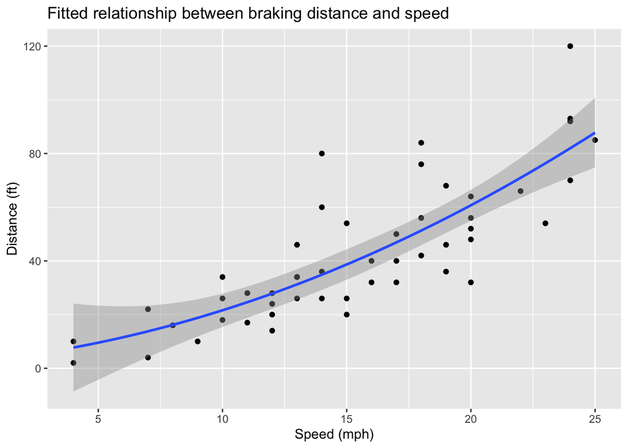

```r
# Load ggplot to enable plotting
library (ggplot2)

#Plot a graph of the fitted relationship between breaking distance and speed.
ggplot(cars, aes(x = speed, y = dist)) + geom_point() +
geom_smooth(method = "lm", formula = y ~ x + I(x^2)) +
labs(title = "Fitted relationship between braking distance and speed",
    x = "Speed (mph)",
    y = "Distance (ft)")
```

#Task 3.8

The count data and sample description files are read into R. For the counts data, row.names = 1 was used to set the first column as row names, and header = TRUE was used to treat the first row as column names. As the sample description file is tab-separated, sep = “ was used alongside header = TRUE to read it correctly.

```r
#Setting the working directory for where the files are stored on my computer.
setwd("/Users/clairearias-alvarez/Desktop/Masters/Advanced_Bioinformatics/LMS_RNAseq_short-master-2023-final/course/exercises/data/")
getwd()
```

```
## [1] "/Users/clairearias-alvarez/Desktop/Masters/Advanced_Bioinformatics/LMS_RNAseq_short-master-2023-final/course/exercises/data"
```

```r
# Read the counts data
counts_data <- read.csv(file = "exercise1_counts.csv", header = T, row.names = 1)
# Read the sample description
sample_des <- read.table("exercise1_sample_description.info", sep = "\t", header = TRUE)
```

```r
#Show the first few rows of the read in counts data
head(counts_data)
```

```
##           control_FFa1.bam control_FFa2.bam control_FFa3.bam mutant_KOa1.bam
## 497097                  16               16                0              21
## 100503874               20                0                0              64
## 100038431                0                0                2               0
## 19888                   11                0               10             113
## 20671                   14               16                0              40
## 27395                  465              193              596             436
##           mutant_KOa2.bam mutant_KOa3.bam mutant_KOb1.bam mutant_KOb2.bam
## 497097                 16              27              20               0
## 100503874               0               4               5               0
## 100038431               0               8               0               0
## 19888                   0              26              14               6
## 20671                   8              33              33              12
## 27395                 686             572            1378            1901
##           mutant_KOb3.bam
## 497097                  2
## 100503874               2
## 100038431               0
## 19888                  16
## 20671                  24
## 27395                1553
```

```r
#Show the first few rows of the read in sample description
head(sample_des)
```

```
##              filename sample condition batch
## 1    control_FFa1.bam   FFa1       FFa     a
## 2    control_FFa2.bam   FFa2       FFa     b
## 3    control_FFa3.bam   FFa3       FFa     c
## 4 TMC_mutant_KOa1.bam   KOa1       KOa     a
## 5 TMC_mutant_KOa2.bam   KOa2       KOa     b
## 6 TMC_mutant_KOa3.bam   KOa3       KOa     c
```

#Task 3.9

Create col_data and check dimensions.

```r
#Create Col data to create a data frame describing each sample, col data was generated from sample description.
col_data <- data.frame(sample = sample_des$sample, condition = sample_des$condition, batch = sample_des$batch)

#Show a few roles of col_data generated
head(col_data)
```

```
##   sample condition batch
## 1   FFa1       FFa     a
## 2   FFa2       FFa     b
## 3   FFa3       FFa     c
## 4   KOa1       KOa     a
## 5   KOa2       KOa     b
## 6   KOa3       KOa     c
```

```r
#Check dimensions
all(colnames(counts_data) == col_data$name)
```

```
## [1] TRUE
```

#Task 3.10

Construct DESeqDataSet object using count data and sample description

```r
# Load DeSeq2 library
suppressPackageStartupMessages(library(DESeq2))
# Create DESeq object
dds <- DESeqDataSetFromMatrix(countData = counts_data, colData = col_data, design =~ condition)
dds
```

```
## class: DESeqDataSet
## dim: 26301 9
## metadata(1): version
## assays(1): counts
## rownames(26301): 497097 100503874 ... 100040384 100040400
## rowData names(0):
## colnames(9): control_FFa1.bam control_FFa2.bam ... mutant_KOb2.bam
##   mutant_KOb3.bam
## colData names(3): sample condition batch
```

#Task 3.11

rlog and VST transformation

```r
# Regularized log transformation of rlog
rlog_data <- rlog(dds)
class(rlog_data)
```

```
## [1] "DESeqTransform"
## attr(,"package")
## [1] "DESeq2"
```

```r
# Regularized log transformation of VST
vst_data <- varianceStabilizingTransformation(dds)
class(vst_data)
```

```
## [1] "DESeqTransform"
## attr(,"package")
## [1] "DESeq2"
```

```r
# The class of the transformed data was checked to confirm that they are DESeqTransform objects
```

#Task 3.12

A heatmap is drawn from the rlog and VST count data. The assay() function extracts the matrix of transformed counts from the DESeq2 object. While, order (rowMeans(), decreasing = TRUE) [1:40],finds the genes with the highest expression levels across all samples and selects the top 40. Following this, pheatmap() is then used to visulalisation and clustering.

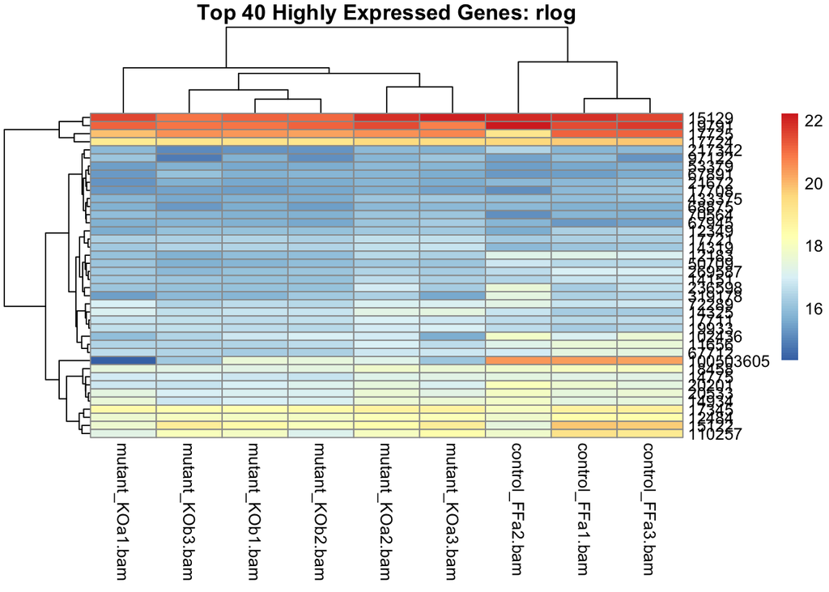

```r
#Load pheatmap library
library("pheatmap")
#Get rlog_data in count format
rlog_counts <- assay(rlog_data)
# Identify the top 40  highly expressed genes in the rlog-transformed dataset
select_rlog <- order(rowMeans(rlog_counts), decreasing = TRUE)[1:40]
# Plot a heatmap using the rlog-transformed expression data
pheatmap(assay(rlog_data)[select_rlog, ], main = "Top 40 Highly Expressed Genes: rlog")
```

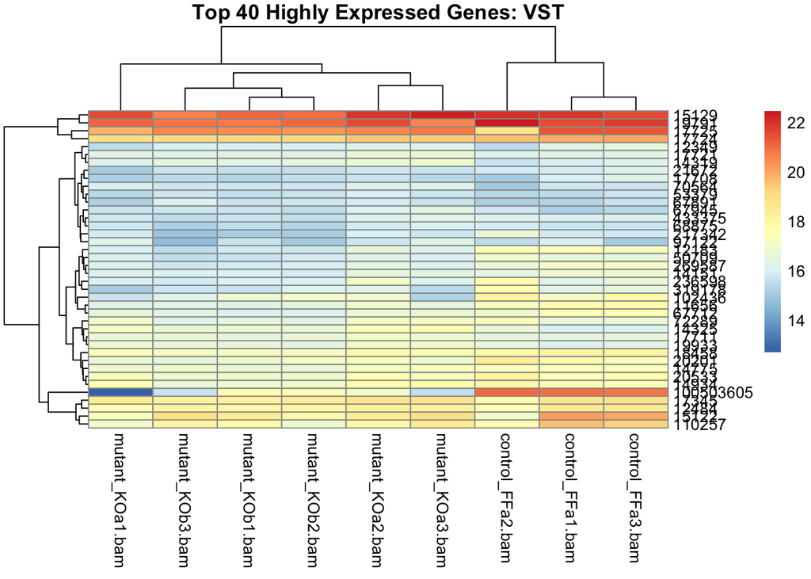

```r
#Get vst_data in count format
vst_counts <- assay(vst_data)
# Identify the top 40  highly expressed genes in the vst-transformed dataset
select_vst <- order(rowMeans(vst_counts), decreasing = TRUE)[1:40]
# Plot a heatmap using the vst-transformed expression data
pheatmap(assay(vst_data)[select_vst, ], main = "Top 40 Highly Expressed Genes: VST")
```

#Task 3.13

A heatmap of the sample distance matrix (SDM) was computed from the rlog transformed count data. This was visualised as using pheatmap(), where samples are labelled by condition on rows making it easier to see the clustering of samples.

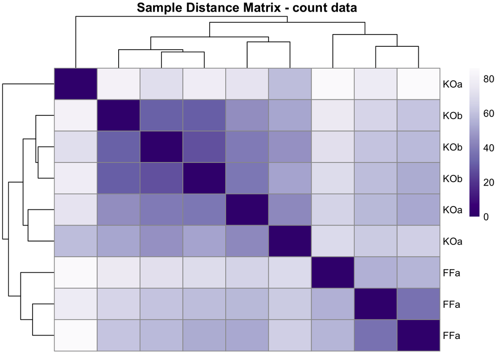

```r
# Compute SDM using rlog transformed data
sample_dist <- dist(t(assay(rlog_data)))
# Transfrom SDM into matrix form
SDM <- as.matrix(sample_dist)

#Load library for colours
library("RColorBrewer")

# Add row names to enable a clearer plot
rownames(SDM) <- rlog_data$condition
colnames (SDM) <-NULL

# Add colors
colors <- colorRampPalette(rev(brewer.pal(9, "Purples")))(255)

# Plot heatmap, library("pheatmap") was previously loaded not needed again.
pheatmap(SDM,
         clustering_distance_rows = sample_dist,
         clustering_distance_cols = sample_dist,
         col = colors,
         main = "Sample Distance Matrix - count data",
         show_rownames = TRUE,
         show_colnames = TRUE)
```

#Task 3.14

```
## using ntop=500 top features by variance
```

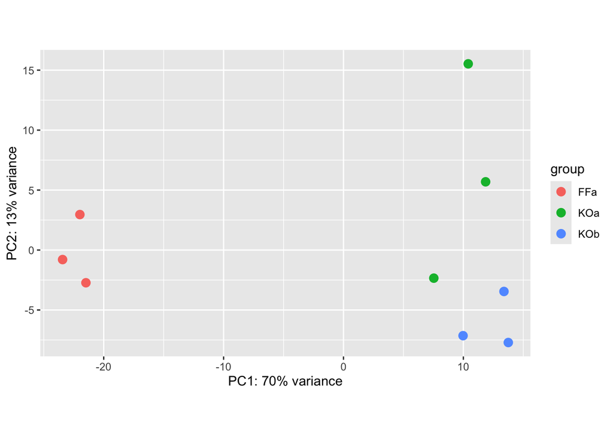

```r
# PCA plot on our rlog_data transformed data
plotPCA(rlog_data, intgroup = "condition")
```

```r
# Store PCA plot data and use returnData = TRUE to extract variance values from the PCA plot
PCA_rlog <- plotPCA(rlog_data, intgroup = "condition", returnData = TRUE)
```

```
## using ntop=500 top features by variance
```

```r
# Extracting the significance percentage values of the first two principle components
percentVar_rlog <- round(100 * attr(PCA_rlog, "percentVar"))
# The percentage significance of PC1
percentVar_rlog[1]
```

```
## [1] 70
```

```r
# The percentage significance of PC2
percentVar_rlog [2]
```

```
## [1] 13
```

#Task 3.15

```
## using ntop=500 top features by variance
```

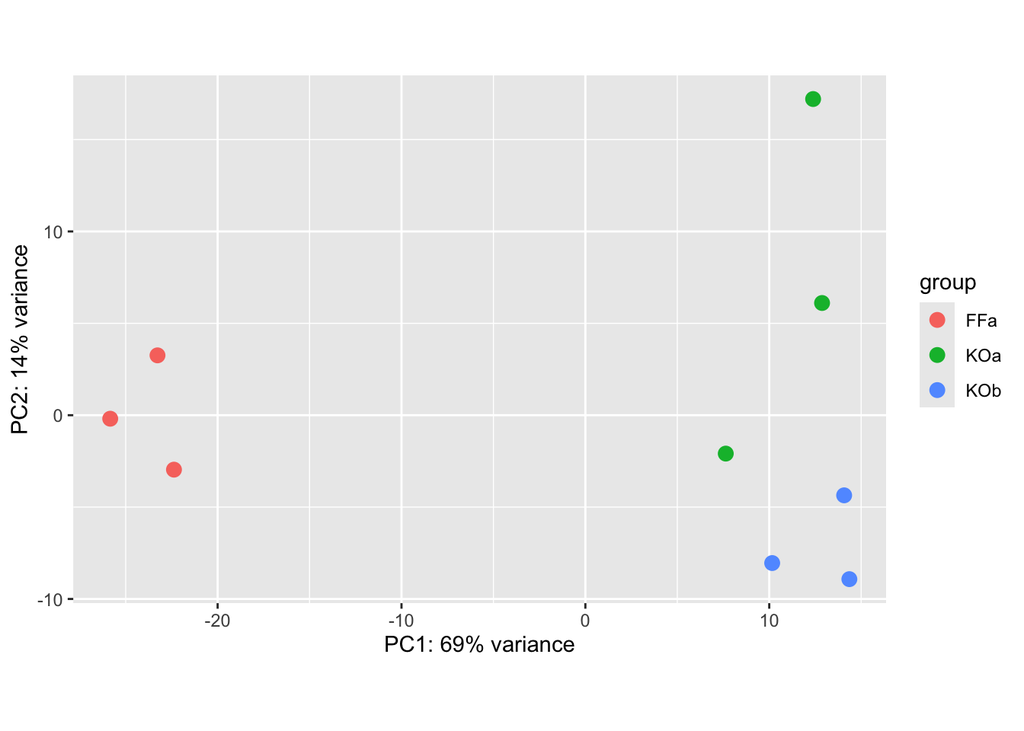

```r
# PCA plot on our vst_data transformed data
plotPCA(vst_data, intgroup = "condition")
```

```r
# Store PCA plot data and use returnData = TRUE to extract variance values from the PCA plot
PCA_vst <- plotPCA(vst_data, intgroup = "condition", returnData = TRUE)
```

```
## using ntop=500 top features by variance
```

```r
# Extracting the significance percentage values of the first two principle components
percentVar_vst <- round(100 * attr(PCA_vst, "percentVar"))
# The percentage significance of PC1
percentVar_vst[1]
```

```
## [1] 69
```

```r
# The percentage significance of PC2
percentVar_vst [2]
```

```
## [1] 14
```